# DATA 624 - PROJECT 2

OMER OZEREN - GRACIE HAN

# Project 2

This is role playing. I am your new boss. I am in charge of production at ABC Beverage and you are a team of data scientists reporting to me. My leadership has told me that new regulations are requiring us to understand our manufacturing process, the predictive factors and be able to report to them our predictive model of PH.

Please use the historical data set I am providing. Build and report the factors in BOTH a technical and non-technical report. I like to use Word and Excel. Please provide your non-technical report in a business friendly readable document and your predictions in an Excel readable format. The technical report should show clearly the models you tested and how you selected your final approach.

Please submit both Rpubs links and .rmd files or other readable formats for technical and non-technical reports. Also submit the excel file showing the prediction of your models for pH

```r
library(tidyverse)
library(kableExtra)
library(xgboost)
library(plyr)
library (e1071)
library(corrplot)
library(ggplot2)
library(tidyr)
library(dplyr)
library(caret)
library(Matrix)
library(writexl)
library(psych)
```

### Load the Evaluation Data

The data set contains 267 observations and 33 variables. The variable name BrandCode is a character variable, the remaining variables are numeric. PH is the respond variable

### Train Data Statistics

```
## [1] 2571   33
```

### Train Data Number of Observations

```
## [1] 2038
```

### Train Data Summary

```
##  Brand.Code   Carb.Volume     Fill.Ounces      PC.Volume       Carb.Pressure
##  A   : 293   Min.   :5.040   Min.   :23.63   Min.   :0.07933   Min.   :57.00
##  B   :1239   1st Qu.:5.293   1st Qu.:23.92   1st Qu.:0.23917   1st Qu.:65.60
##  C   : 304   Median :5.347   Median :23.97   Median :0.27133   Median :68.20
##  D   : 615   Mean   :5.370   Mean   :23.97   Mean   :0.27712   Mean   :68.19
##  NA's: 120   3rd Qu.:5.453   3rd Qu.:24.03   3rd Qu.:0.31200   3rd Qu.:70.60
##              Max.   :5.700   Max.   :24.32   Max.   :0.47800   Max.   :79.40
##              NA's   :10      NA's   :38      NA's   :39        NA's   :27
##    Carb.Temp          PSC             PSC.Fill         PSC.CO2
##  Min.   :128.6   Min.   :0.00200   Min.   :0.0000   Min.   :0.00000
##  1st Qu.:138.4   1st Qu.:0.04800   1st Qu.:0.1000   1st Qu.:0.02000
##  Median :140.8   Median :0.07600   Median :0.1800   Median :0.04000
##  Mean   :141.1   Mean   :0.08457   Mean   :0.1954   Mean   :0.05641
##  3rd Qu.:143.8   3rd Qu.:0.11200   3rd Qu.:0.2600   3rd Qu.:0.08000
##  Max.   :154.0   Max.   :0.27000   Max.   :0.6200   Max.   :0.24000
##  NA's   :26      NA's   :33        NA's   :23       NA's   :39
##     Mnf.Flow       Carb.Pressure1  Fill.Pressure   Hyd.Pressure1
##  Min.   :-100.20   Min.   :105.6   Min.   :34.60   Min.   :-0.80
##  1st Qu.:-100.00   1st Qu.:119.0   1st Qu.:46.00   1st Qu.: 0.00
##  Median :  65.20   Median :123.2   Median :46.40   Median :11.40
##  Mean   :  24.57   Mean   :122.6   Mean   :47.92   Mean   :12.44
##  3rd Qu.: 140.80   3rd Qu.:125.4   3rd Qu.:50.00   3rd Qu.:20.20
##  Max.   : 229.40   Max.   :140.2   Max.   :60.40   Max.   :58.00
##  NA's   :2         NA's   :32      NA's   :22      NA's   :11
##  Hyd.Pressure2   Hyd.Pressure3   Hyd.Pressure4     Filler.Level
##  Min.   : 0.00   Min.   :-1.20   Min.   : 52.00   Min.   : 55.8
##  1st Qu.: 0.00   1st Qu.: 0.00   1st Qu.: 86.00   1st Qu.: 98.3
##  Median :28.60   Median :27.60   Median : 96.00   Median :118.4
##  Mean   :20.96   Mean   :20.46   Mean   : 96.29   Mean   :109.3
##  3rd Qu.:34.60   3rd Qu.:33.40   3rd Qu.:102.00   3rd Qu.:120.0
##  Max.   :59.40   Max.   :50.00   Max.   :142.00   Max.   :161.2
##  NA's   :15      NA's   :15      NA's   :30       NA's   :20
##   Filler.Speed   Temperature      Usage.cont      Carb.Flow       Density
##  Min.   : 998   Min.   :63.60   Min.   :12.08   Min.   :  26   Min.   :0.240
##  1st Qu.:3888   1st Qu.:65.20   1st Qu.:18.36   1st Qu.:1144   1st Qu.:0.900
##  Median :3982   Median :65.60   Median :21.79   Median :3028   Median :0.980
##  Mean   :3687   Mean   :65.97   Mean   :20.99   Mean   :2468   Mean   :1.174
##  3rd Qu.:3998   3rd Qu.:66.40   3rd Qu.:23.75   3rd Qu.:3186   3rd Qu.:1.620
##  Max.   :4030   Max.   :76.20   Max.   :25.90   Max.   :5104   Max.   :1.920
##  NA's   :57     NA's   :14      NA's   :5       NA's   :2      NA's   :1
```

[output cut: 9 more lines]

```
##  Min.   :0.00240   Min.   : 70.0   Min.   :44.00     Min.   :140.8
##  1st Qu.:0.02200   1st Qu.:100.0   1st Qu.:46.00     1st Qu.:142.2
##  Median :0.03340   Median :120.0   Median :46.00     Median :142.6
##  Mean   :0.04684   Mean   :109.3   Mean   :47.62     Mean   :142.8
##  3rd Qu.:0.06000   3rd Qu.:120.0   3rd Qu.:50.00     3rd Qu.:143.0
##  Max.   :0.40000   Max.   :140.0   Max.   :52.00     Max.   :148.2
##  NA's   :12        NA's   :2       NA's   :12
##     Alch.Rel        Carb.Rel      Balling.Lvl
##  Min.   :5.280   Min.   :4.960   Min.   :0.00
##  1st Qu.:6.540   1st Qu.:5.340   1st Qu.:1.38
##  Median :6.560   Median :5.400   Median :1.48
##  Mean   :6.897   Mean   :5.437   Mean   :2.05
##  3rd Qu.:7.240   3rd Qu.:5.540   3rd Qu.:3.14
##  Max.   :8.620   Max.   :6.060   Max.   :3.66
##  NA's   :9       NA's   :10      NA's   :1
```

The training data set contains 2571 observations and 33 variables. The variable name BrandCode is a character variable, the remaining variables are numeric. PH is the response variable.

### Summary Statistics of Train Data

```
##                   vars    n    mean      sd  median trimmed    mad     min
## Brand.Code*          1 2451    2.51    1.00    2.00    2.51   0.00    1.00
## Carb.Volume          2 2561    5.37    0.11    5.35    5.37   0.11    5.04
## Fill.Ounces          3 2533   23.97    0.09   23.97   23.98   0.08   23.63
## PC.Volume            4 2532    0.28    0.06    0.27    0.27   0.05    0.08
## Carb.Pressure        5 2544   68.19    3.54   68.20   68.12   3.56   57.00
## Carb.Temp            6 2545  141.09    4.04  140.80  140.99   3.85  128.60
## PSC                  7 2538    0.08    0.05    0.08    0.08   0.05    0.00
## PSC.Fill             8 2548    0.20    0.12    0.18    0.18   0.12    0.00
## PSC.CO2              9 2532    0.06    0.04    0.04    0.05   0.03    0.00
## Mnf.Flow            10 2569   24.57  119.48   65.20   21.07 169.02 -100.20
## Carb.Pressure1      11 2539  122.59    4.74  123.20  122.54   4.45  105.60
## Fill.Pressure       12 2549   47.92    3.18   46.40   47.71   2.37   34.60
## Hyd.Pressure1       13 2560   12.44   12.43   11.40   10.84  16.90   -0.80
## Hyd.Pressure2       14 2556   20.96   16.39   28.60   21.05  13.34    0.00
## Hyd.Pressure3       15 2556   20.46   15.98   27.60   20.51  13.94   -1.20
## Hyd.Pressure4       16 2541   96.29   13.12   96.00   95.45  11.86   52.00
## Filler.Level        17 2551  109.25   15.70  118.40  111.04   9.19   55.80
## Filler.Speed        18 2514 3687.20  770.82 3982.00 3919.99  47.44  998.00
## Temperature         19 2557   65.97    1.38   65.60   65.80   0.89   63.60
## Usage.cont          20 2566   20.99    2.98   21.79   21.25   3.19   12.08
## Carb.Flow           21 2569 2468.35 1073.70 3028.00 2601.14 326.17   26.00
## Density             22 2570    1.17    0.38    0.98    1.15   0.15    0.24
## MFR                 23 2359  704.05   73.90  724.00  718.16  15.42   31.40
## Balling             24 2570    2.20    0.93    1.65    2.13   0.37   -0.17
## Pressure.Vacuum     25 2571   -5.22    0.57   -5.40   -5.25   0.59   -6.60
## PH                  26 2567    8.55    0.17    8.54    8.55   0.18    7.88
## Oxygen.Filler       27 2559    0.05    0.05    0.03    0.04   0.02    0.00
## Bowl.Setpoint       28 2569  109.33   15.30  120.00  111.35   0.00   70.00
## Pressure.Setpoint   29 2559   47.62    2.04   46.00   47.60   0.00   44.00
## Air.Pressurer       30 2571  142.83    1.21  142.60  142.58   0.59  140.80
## Alch.Rel            31 2562    6.90    0.51    6.56    6.84   0.06    5.28
## Carb.Rel            32 2561    5.44    0.13    5.40    5.43   0.12    4.96
## Balling.Lvl         33 2570    2.05    0.87    1.48    1.98   0.21    0.00
##                       max   range  skew kurtosis    se
## Brand.Code*          4.00    3.00  0.38    -1.06  0.02
## Carb.Volume          5.70    0.66  0.39    -0.47  0.00
## Fill.Ounces         24.32    0.69 -0.02     0.86  0.00
## PC.Volume            0.48    0.40  0.34     0.67  0.00
## Carb.Pressure       79.40   22.40  0.18    -0.01  0.07
```

[output cut: 13 more lines]

```
## Temperature         76.20   12.60  2.39    10.16  0.03
## Usage.cont          25.90   13.82 -0.54    -1.02  0.06
## Carb.Flow         5104.00 5078.00 -0.99    -0.58 21.18
## Density              1.92    1.68  0.53    -1.20  0.01
## MFR                868.60  837.20 -5.09    30.46  1.52
## Balling              4.01    4.18  0.59    -1.39  0.02
## Pressure.Vacuum     -3.60    3.00  0.53    -0.03  0.01
## PH                   9.36    1.48 -0.29     0.06  0.00
## Oxygen.Filler        0.40    0.40  2.66    11.09  0.00
## Bowl.Setpoint      140.00   70.00 -0.97    -0.06  0.30
## Pressure.Setpoint   52.00    8.00  0.20    -1.60  0.04
## Air.Pressurer      148.20    7.40  2.25     4.73  0.02
## Alch.Rel             8.62    3.34  0.88    -0.85  0.01
## Carb.Rel             6.06    1.10  0.50    -0.29  0.00
## Balling.Lvl          3.66    3.66  0.59    -1.49  0.02
```

#### Visualization of Target Variable (pH)

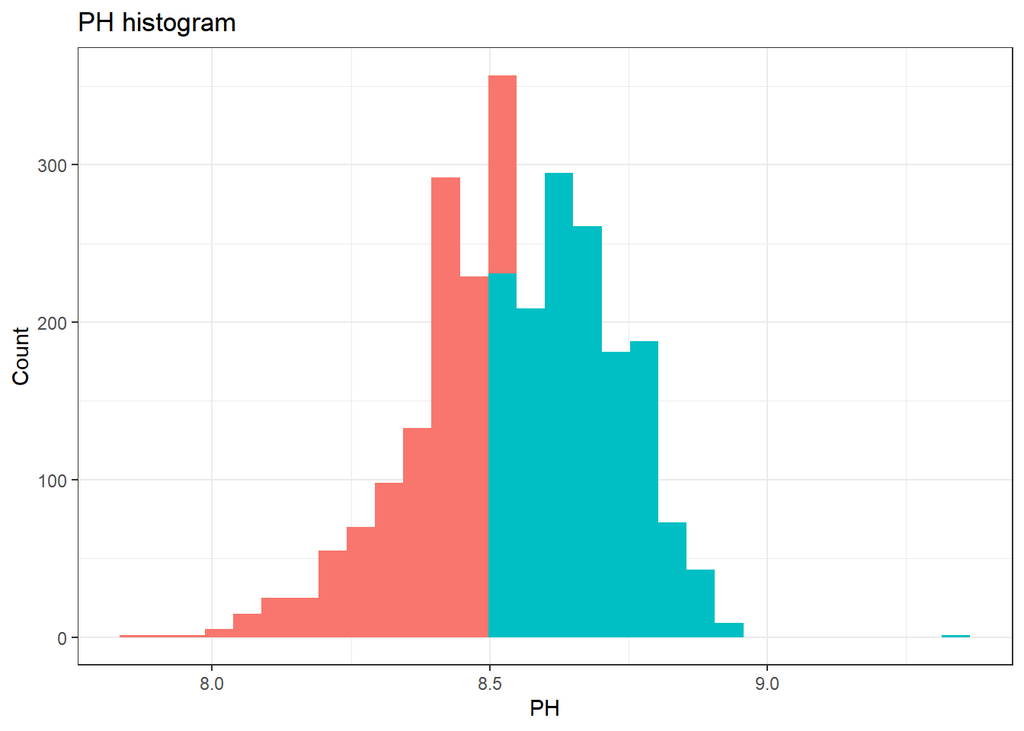

The outcome variable, PH value in the beverage, is shown on histogram here. We can see that it is a continuous variable with no gap at no clear patterns of missing value.

Except a few observations which is somewhat outliers at the right tale, it pretty much follows a normal distribution. There are slightly more observations on the right side ( higher values ) of the histogram, but we decide not to do too much about it because the s Skewness is minimum.

We decided that this outcome is satisfactory in being used as is as a numerical variable outcome. We will provide models based on PH outcome as a continuous numerical variable, without intentional cutoff points below.

### Visualization of Predictors

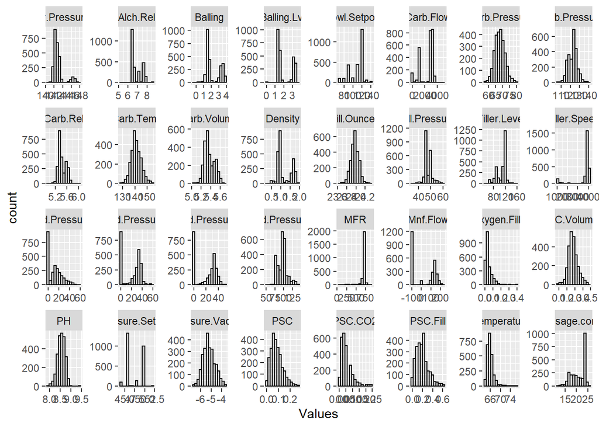

Visualization of histogram of each individual predictor variables indicate that beside the numerical variables, there are many categorical variables (discrete variables), such as pressure.set point, aich.rel).

The obvious discrete variables are: Brand Code (ABCD 4 brands in total), Pressure Setpoint, Bowl Setpoint, PSC.CO2, Pressure Vacuume. Each of these varaiables have no more than 10-12 unique numbers to make the count.

There are some bi-mode variables: (such as pressure set point, density, hyd pressure 2, hyd pressure3).  
Multi-mode (>2mode) Variables include carb flow.

These variables have a significant numbers of apps observations at 0: hyd pressure1,hyd pressure2,hyd pressure 3,

The close to normally distributed variables judging from the histograms are : carb pressure 1, carb pressure 2, Carb Temp, Carb Volume, Fill Ounces, PC Volume.

We chose bins=15 and facet wrap for the histograms. This findings are preserved after changing the numbers of bins.

### Outliers Analysis with Boxplot

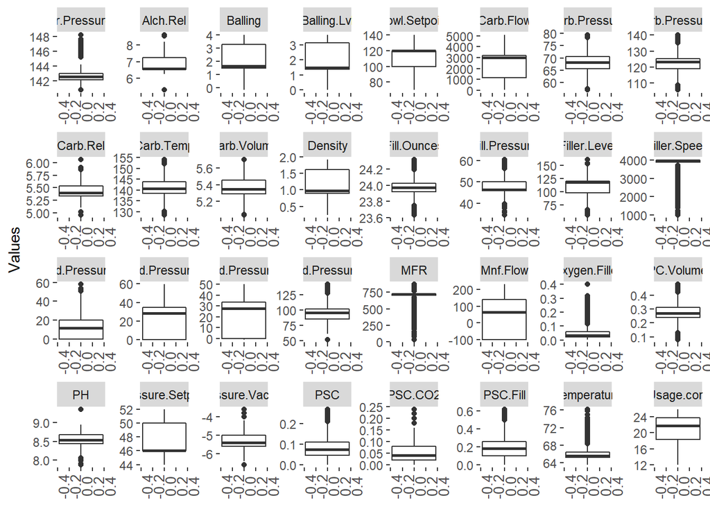

Because some of the variables are skewed, so the box plot shows data many of these predictors are recognized as outliers. these variables include: - MFR , - filler.speed, - Oxygen,filler, - Air.presseurer. But we predict that after transformation later on, some of these so called “outliers” will not persist. Besides the above mentioned four variables, these variables also have extreme outliers: - PSC fill, - PSC CO2, - Temperature, - Pressure.vacume, - Alch.Rel, - Carb.Rel.

Interestingly, the outcome variable pH also have a few outliers.

### Relationships Between the Target and Explanatory Variables

This plot below indicates relationship between target and explanatory variables

[figure not shown]

Among all 33 predicted variables my, majority of them have clear Association with the outcome. Maybe half of these predictors, if they are numerical and continuous, have clear relationship to the outcome in linear fashion. The predictors that clear Le demonstrate the linearity with the outcome include below:

Carb volume, fill ounces, PC volumes, carb pressure, carb temperatures, PSC fill, PSC, carb pressure1, carb rel.

Explaining these variables from common sense perspective, they all make sense in beverage production, we feel that these variables are the predictors that have good and continuous measurement, oftentimes from the environment, rather than work worker controlled source. Therefore, it is not surprising that they have good linearity with the pH value (outcome) of the beverage.

Above is the good news from predictors, which favors linear model, as well as other tree based the models. However, we have also seen that many other variables, even that they are linear and numerical predictors, they either have outliers, or their measure month is not continuous enough, in other words, interrupted in patterns, therefore may produce errors if we fit the linear model two outcome directly without tuning of these variables, or without other sophisticated modeling. Such non perfect numerical predictor variables include:

Mnf Flow, fill pressure, Hyd pressure 1, Hyd Pressure2, Hyd pressure3, Fill levels, Filler Speed, temperature, carb flow, MFR, Density, Bailing, Oxygen Filler, Air Pressure

Finally many of the predictor variables are in discrete or nominal variable fashion, which has levels in less than 10 or even 3. so when we fit these variables into the model, we have to be oh extremely careful that the levels of predictors can be overly simplified in terms of explanation due to the overly crude way of describing the nature of this variable.

### Correlation

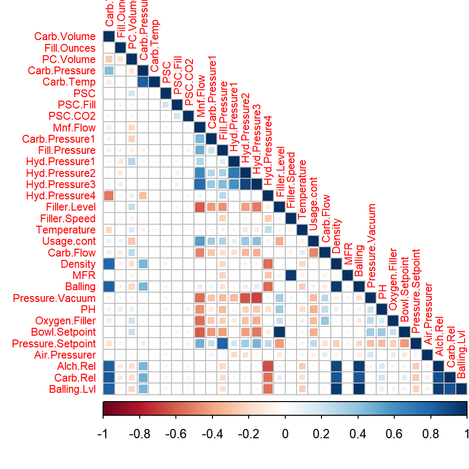

We find the following very strong correlations: - Carb.Volume with Density, Balling, Alch.Rel, Carb.Rel, and Balling.Lvl. - Carb.Pressure with Carb.Temp - Filler.Level with Bowl.Setpoint - Filler.Speed with MFR

Correlation plot above indicates that some explanantory variables are correleted each other.

We find out explanantory variables that hig correleted each other by using findCorrelation() with using threshold as 0.6.

```
##  [1] "Mnf.Flow"      "Balling"       "Hyd.Pressure3" "Alch.Rel"
##  [5] "Balling.Lvl"   "Carb.Rel"      "Density"       "Hyd.Pressure2"
##  [9] "Fill.Pressure" "Filler.Level"  "Carb.Pressure" "Filler.Speed"
```

Below shows top 10 Explanatory variables that positively correleted highly to PH

```
##            rowname         PH
## 1               PH 1.00000000
## 2    Bowl.Setpoint 0.36158753
## 3     Filler.Level 0.35204396
## 4        Carb.Flow 0.23359370
## 5  Pressure.Vacuum 0.21973550
## 6         Carb.Rel 0.19605148
## 7         Alch.Rel 0.16668223
## 8    Oxygen.Filler 0.16448536
## 9      Balling.Lvl 0.10937117
## 10       PC.Volume 0.09886673
```

Bowl Setpoint, Filler Level, Carb Flow, Pressure Vacuum are the top 5 explanatory variables that are positively associated with the PH outcome.

Their correlation to the PH outcome rANGES FROM 0.36 (TOP1) TO 0.22 (TOP 5TH).

The next set of varialbes (top 6-top10) have a correlation to outcome range from 0.196 (top 6th) to 0.098 (top 10th).

Below shows top 10 Explanatory variables that negatively correlated highly to PH

```
##              rowname         PH
## 1           Mnf.Flow -0.4592313
## 2         Usage.cont -0.3576120
## 3      Fill.Pressure -0.3165145
## 4  Pressure.Setpoint -0.3116639
## 5      Hyd.Pressure3 -0.2681018
## 6      Hyd.Pressure2 -0.2226600
## 7        Temperature -0.1826596
## 8      Hyd.Pressure4 -0.1714340
## 9     Carb.Pressure1 -0.1187642
## 10       Fill.Ounces -0.1183359
```

Mnf Flow stands out as the top 1 variable that is negatively associated with the PH outcome (correlation = -0.46), with a much higher correlation than the 2nd variable Usage Count (correlation at -0.35).

### Near Zero Variance Predictors

```
## [1] 13
```

“Hyd Pressure1” should be removed from the dataset since it hold constant values.WE are going to handle this in Model Data PreProcessing part

### Missing Values

Using VIM library to explore missing values.

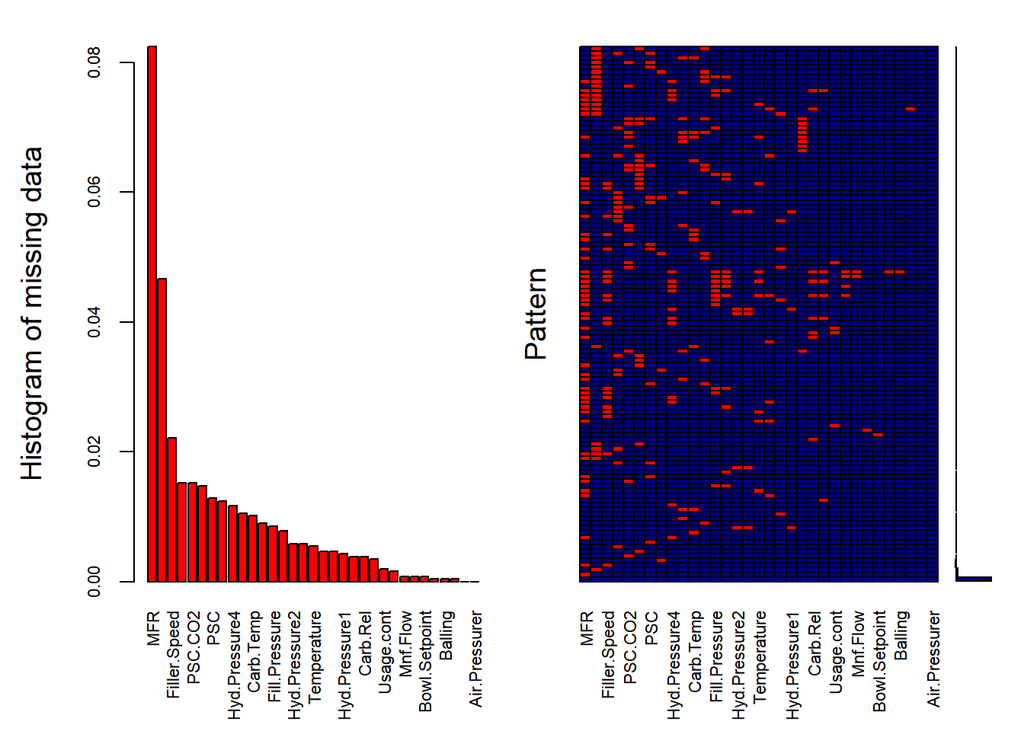

```
##
##  Variables sorted by number of missings:
##           Variable        Count
##                MFR 0.0824581875
##         Brand.Code 0.0466744457
##       Filler.Speed 0.0221703617
##          PC.Volume 0.0151691949
##            PSC.CO2 0.0151691949
##        Fill.Ounces 0.0147802412
##                PSC 0.0128354726
##     Carb.Pressure1 0.0124465189
##      Hyd.Pressure4 0.0116686114
##      Carb.Pressure 0.0105017503
##          Carb.Temp 0.0101127966
##           PSC.Fill 0.0089459354
##      Fill.Pressure 0.0085569817
##       Filler.Level 0.0077790743
##      Hyd.Pressure2 0.0058343057
##      Hyd.Pressure3 0.0058343057
##        Temperature 0.0054453520
##      Oxygen.Filler 0.0046674446
##  Pressure.Setpoint 0.0046674446
##      Hyd.Pressure1 0.0042784909
##        Carb.Volume 0.0038895371
##           Carb.Rel 0.0038895371
##           Alch.Rel 0.0035005834
##         Usage.cont 0.0019447686
##                 PH 0.0015558149
##           Mnf.Flow 0.0007779074
##          Carb.Flow 0.0007779074
##      Bowl.Setpoint 0.0007779074
##            Density 0.0003889537
##            Balling 0.0003889537
##        Balling.Lvl 0.0003889537
##    Pressure.Vacuum 0.0000000000
##      Air.Pressurer 0.0000000000
```

MFR stands out as a Having a significant amount of missings.

Followed by fillet speed, pace co2.

The pattern of MR indicates that it has more missing values at the high end, and the also in the middle part.

## Modeling Data PreProcessing

```
##  Brand.Code  Carb.Volume     Fill.Ounces      PC.Volume       Carb.Pressure
##  A: 305     Min.   :5.040   Min.   :23.63   Min.   :0.07933   Min.   :57.00
##  B:1312     1st Qu.:5.293   1st Qu.:23.92   1st Qu.:0.23933   1st Qu.:65.60
##  C: 333     Median :5.347   Median :23.97   Median :0.27133   Median :68.20
##  D: 621     Mean   :5.370   Mean   :23.97   Mean   :0.27781   Mean   :68.22
##             3rd Qu.:5.453   3rd Qu.:24.03   3rd Qu.:0.31267   3rd Qu.:70.60
##             Max.   :5.700   Max.   :24.32   Max.   :0.47800   Max.   :79.40
##    Carb.Temp          PSC           PSC.Fill         PSC.CO2
##  Min.   :128.6   Min.   :0.002   Min.   :0.0000   Min.   :0.00000
##  1st Qu.:138.4   1st Qu.:0.048   1st Qu.:0.1000   1st Qu.:0.02000
##  Median :140.8   Median :0.078   Median :0.1800   Median :0.04000
##  Mean   :141.1   Mean   :0.085   Mean   :0.1958   Mean   :0.05644
##  3rd Qu.:143.8   3rd Qu.:0.112   3rd Qu.:0.2600   3rd Qu.:0.08000
##  Max.   :154.0   Max.   :0.270   Max.   :0.6200   Max.   :0.24000
##     Mnf.Flow       Carb.Pressure1  Fill.Pressure   Hyd.Pressure2
##  Min.   :-100.20   Min.   :105.6   Min.   :34.60   Min.   : 0.00
##  1st Qu.:-100.00   1st Qu.:118.8   1st Qu.:46.00   1st Qu.: 0.00
##  Median :  64.80   Median :123.2   Median :46.40   Median :28.60
##  Mean   :  24.47   Mean   :122.5   Mean   :47.92   Mean   :20.97
##  3rd Qu.: 140.80   3rd Qu.:125.4   3rd Qu.:50.00   3rd Qu.:34.60
##  Max.   : 229.40   Max.   :140.2   Max.   :60.40   Max.   :59.40
##  Hyd.Pressure3   Hyd.Pressure4     Filler.Level    Filler.Speed
##  Min.   :-1.20   Min.   : 52.00   Min.   : 55.8   Min.   : 998
##  1st Qu.: 0.00   1st Qu.: 86.00   1st Qu.: 97.7   1st Qu.:3819
##  Median :27.60   Median : 96.00   Median :118.4   Median :3980
##  Mean   :20.44   Mean   : 96.53   Mean   :109.2   Mean   :3637
##  3rd Qu.:33.20   3rd Qu.:102.00   3rd Qu.:120.0   3rd Qu.:3996
##  Max.   :50.00   Max.   :142.00   Max.   :161.2   Max.   :4030
##   Temperature      Usage.cont      Carb.Flow       Density           MFR
##  Min.   :63.60   Min.   :12.08   Min.   :  26   Min.   :0.240   Min.   : 31.4
##  1st Qu.:65.20   1st Qu.:18.36   1st Qu.:1142   1st Qu.:0.900   1st Qu.:695.0
##  Median :65.60   Median :21.78   Median :3028   Median :0.980   Median :721.4
##  Mean   :65.98   Mean   :20.99   Mean   :2468   Mean   :1.174   Mean   :669.8
##  3rd Qu.:66.40   3rd Qu.:23.75   3rd Qu.:3186   3rd Qu.:1.620   3rd Qu.:730.4
##  Max.   :76.20   Max.   :25.90   Max.   :5104   Max.   :1.920   Max.   :868.6
##     Balling       Pressure.Vacuum        PH        Oxygen.Filler
##  Min.   :-0.170   Min.   :-6.600   Min.   :7.880   Min.   :0.00240
##  1st Qu.: 1.496   1st Qu.:-5.600   1st Qu.:8.440   1st Qu.:0.02200
##  Median : 1.648   Median :-5.400   Median :8.540   Median :0.03340
##  Mean   : 2.198   Mean   :-5.216   Mean   :8.546   Mean   :0.04712
##  3rd Qu.: 3.292   3rd Qu.:-5.000   3rd Qu.:8.680   3rd Qu.:0.06000
##  Max.   : 4.012   Max.   :-3.600   Max.   :9.360   Max.   :0.40000
##  Bowl.Setpoint   Pressure.Setpoint Air.Pressurer      Alch.Rel
##  Min.   : 70.0   Min.   :44.00     Min.   :140.8   Min.   :5.280
##  1st Qu.:100.0   1st Qu.:46.00     1st Qu.:142.2   1st Qu.:6.540
##  Median :120.0   Median :46.00     Median :142.6   Median :6.560
##  Mean   :109.3   Mean   :47.61     Mean   :142.8   Mean   :6.897
##  3rd Qu.:120.0   3rd Qu.:50.00     3rd Qu.:143.0   3rd Qu.:7.240
##  Max.   :140.0   Max.   :52.00     Max.   :148.2   Max.   :8.620
##     Carb.Rel      Balling.Lvl
##  Min.   :4.960   Min.   :0.00
##  1st Qu.:5.340   1st Qu.:1.38
##  Median :5.400   Median :1.48
##  Mean   :5.436   Mean   :2.05
##  3rd Qu.:5.540   3rd Qu.:3.14
##  Max.   :6.060   Max.   :3.66
```

We used MICE package, CMM method to impute the missing data.

For the variables that has near zero observations, we used the function of nearzeroVar, to avoid imputing the missing zeros.

From previous data exploration, we know that the non-zero observations occur most in the variables of HYD pressure1.

By choosing not to impute the variable of HYD pressure1 (with non zeros), in the evaluated model, we exclude that variable.

let’s look at the variables missing percentage after impution to check if we missing anything.

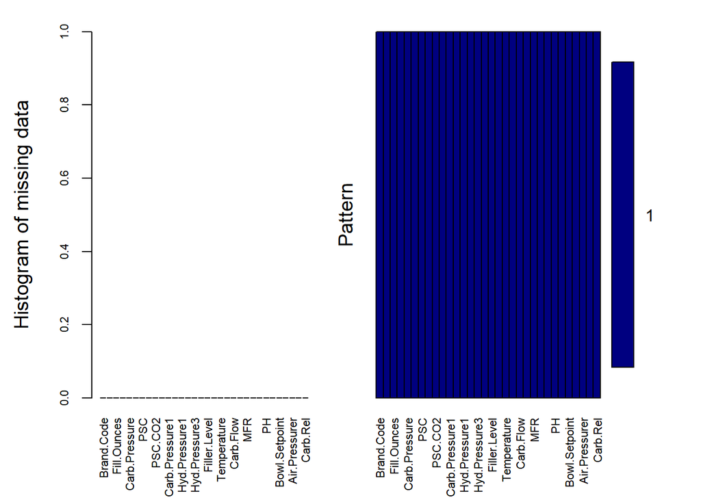

```
##
##  Variables sorted by number of missings:
##           Variable Count
##         Brand.Code     0
##        Carb.Volume     0
##        Fill.Ounces     0
##          PC.Volume     0
##      Carb.Pressure     0
##          Carb.Temp     0
##                PSC     0
##           PSC.Fill     0
##            PSC.CO2     0
##           Mnf.Flow     0
##     Carb.Pressure1     0
##      Fill.Pressure     0
##      Hyd.Pressure1     0
##      Hyd.Pressure2     0
##      Hyd.Pressure3     0
##      Hyd.Pressure4     0
##       Filler.Level     0
##       Filler.Speed     0
##        Temperature     0
##         Usage.cont     0
##          Carb.Flow     0
##            Density     0
##                MFR     0
##            Balling     0
##    Pressure.Vacuum     0
##                 PH     0
##      Oxygen.Filler     0
##      Bowl.Setpoint     0
##  Pressure.Setpoint     0
##      Air.Pressurer     0
##           Alch.Rel     0
##           Carb.Rel     0
```

By using the aggr function, we visualized the missing variables again.

We can see that on the left side graph, there is no missing values from the data anymore. On the right side, the figure shows that all the missing variables are now complete.

### Splitting Data Set

Splitting dataset into training and test sets.

We used the 80/20 rule to create the training data set and the testing data set. The function of createDataPartition is used for that purpose, which select the random sample from the completed Data. Here, completed means imputed data.

## Model Building & Evaluation

Now the Data has been evaluated, with missing that is imputed. The Data is ready to go for various of Modeling effort.

First,before any modeling occured, we created an empty data frame called models_test_evaluation, which is the place holder for all the model evaluates. For each model, we will select Root Mean Square of Error (RMSE), R-squared, Mean Aboslute Error (MAE). Once these evaluators are available from the model run, they are put into this dataframe, one row per modeling.

We first will run the traditional linear regression model, as we have numerical outcome, and mostly numerical predictors.

Next we will apply a few of the tree-based model and rule based models, which are more modern, and utilizing the 33 variables in an ensumble (or bagged way/mechanism), rather than assuming all linearity relationship to the outcome for all 33 predictor variables indiviually, Which as we know is a very strict assumption, and our data does not fully support that assumption.

Most of the variables are associated with outcome, but not in the linear fashion.

### Linear Regression Model

```
##
## Call:
## lm(formula = PH ~ ., data = train_data)
##
## Residuals:
##      Min       1Q   Median       3Q      Max
## -0.51863 -0.07572  0.01150  0.08913  0.85621
##
## Coefficients:
##                     Estimate Std. Error t value Pr(>|t|)
## (Intercept)        1.028e+01  1.180e+00   8.714  < 2e-16 ***
## Brand.CodeB        3.533e-02  2.215e-02   1.595 0.110876
## Brand.CodeC       -8.893e-02  2.212e-02  -4.020 6.03e-05 ***
## Brand.CodeD        6.722e-02  1.821e-02   3.692 0.000228 ***
## Carb.Volume       -5.349e-02  1.001e-01  -0.535 0.593019
## Fill.Ounces       -6.645e-02  3.542e-02  -1.876 0.060798 .
## PC.Volume         -1.056e-01  5.824e-02  -1.813 0.069929 .
## Carb.Pressure     -5.154e-04  4.680e-03  -0.110 0.912319
## Carb.Temp          1.645e-03  3.707e-03   0.444 0.657278
## PSC               -1.262e-01  6.481e-02  -1.948 0.051597 .
## PSC.Fill          -4.041e-02  2.621e-02  -1.542 0.123253
## PSC.CO2           -1.537e-01  7.024e-02  -2.189 0.028745 *
## Mnf.Flow          -7.433e-04  5.227e-05 -14.219  < 2e-16 ***
## Carb.Pressure1     7.509e-03  7.919e-04   9.482  < 2e-16 ***
## Fill.Pressure      1.217e-03  1.334e-03   0.912 0.361679
## Hyd.Pressure2     -1.081e-03  5.409e-04  -1.998 0.045835 *
## Hyd.Pressure3      3.537e-03  6.617e-04   5.346 1.00e-07 ***
## Hyd.Pressure4     -1.032e-06  3.627e-04  -0.003 0.997731
## Filler.Level      -1.342e-03  6.607e-04  -2.032 0.042291 *
## Filler.Speed       9.271e-06  1.284e-05   0.722 0.470236
## Temperature       -1.106e-02  2.459e-03  -4.500 7.18e-06 ***
## Usage.cont        -6.851e-03  1.283e-03  -5.338 1.05e-07 ***
## Carb.Flow          1.087e-05  4.245e-06   2.559 0.010559 *
## Density           -1.150e-01  3.081e-02  -3.731 0.000196 ***
## MFR               -3.836e-05  7.197e-05  -0.533 0.594133
## Balling           -7.739e-02  2.689e-02  -2.878 0.004043 **
## Pressure.Vacuum   -1.773e-02  8.510e-03  -2.084 0.037314 *
## Oxygen.Filler     -2.484e-01  7.854e-02  -3.162 0.001588 **
## Bowl.Setpoint      3.520e-03  6.921e-04   5.086 3.99e-07 ***
## Pressure.Setpoint -7.921e-03  2.166e-03  -3.656 0.000263 ***
## Air.Pressurer     -2.158e-03  2.617e-03  -0.825 0.409748
## Alch.Rel           4.368e-02  2.384e-02   1.832 0.067050 .
## Carb.Rel          -5.355e-03  5.215e-02  -0.103 0.918237
## Balling.Lvl        1.015e-01  2.487e-02   4.083 4.62e-05 ***
## ---
## Signif. codes:  0 '***' 0.001 '**' 0.01 '*' 0.05 '.' 0.1 ' ' 1
##
## Residual standard error: 0.1336 on 2024 degrees of freedom
## Multiple R-squared:  0.4041, Adjusted R-squared:  0.3943
## F-statistic: 41.59 on 33 and 2024 DF,  p-value: < 2.2e-16
```

First, we run linear regression model. This is our basic banhmark model.

Because linear regression is a traditional model, and our data contains mostly numerical continuous variable, and our outcome pH is also continuous variable. Therefore we first chose linear model as the basic machine learning technique to predict the beverage’s PH outcome.

We used the LM function for linear regression model. All variables are fitted directly into them model as it was defined in the original data, with missing that is filled in.

The next few models are all assuming non-linear fashion, which are more popular machine learning algorithms and also more truthful to this data prediction. We chosed a few tree-based modeling.

The ensemble techniques of the nonlinear models have a few advantages. By packing or bagging the variables into trees,the variance of a prediction through these ensemble process are reduced, which fit even the unstable predictions with less stringent assumption than linear model.

### Bagged Tree Model

```
##
## Call:
## bag.default(x = x, y = y, vars = param$vars, bagControl = ..1, center =
##  TRUE, scale = TRUE)
##
## Out of bag statistics (B = 10):
##
##          RMSE Rsquared     MAE
##   0.0% 0.1207   0.4154 0.09003
##   2.5% 0.1220   0.4184 0.09089
##  25.0% 0.1271   0.4340 0.09591
##  50.0% 0.1302   0.4580 0.09683
##  75.0% 0.1325   0.4746 0.09708
##  97.5% 0.1328   0.5055 0.09821
## 100.0% 0.1329   0.5135 0.09831
```

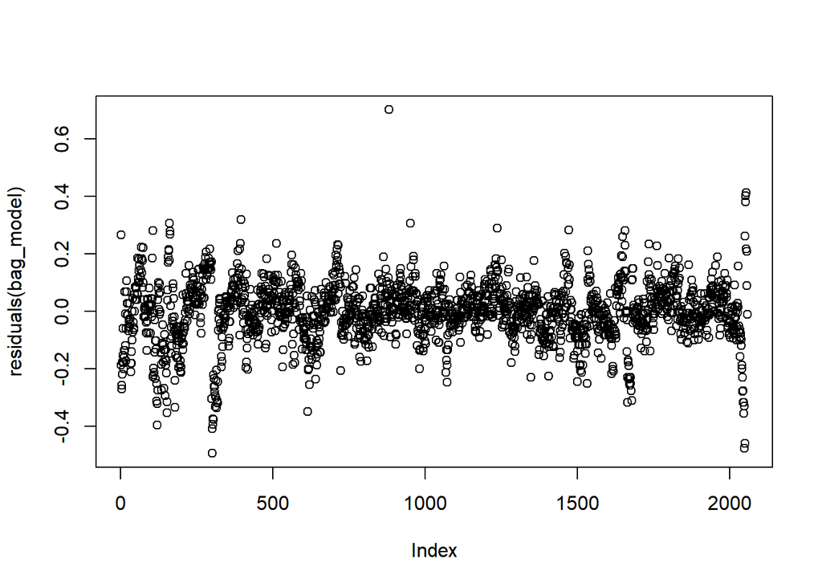

First tree based models We selected in is bagged tree model. Each Model in the bagged tree ensemble is used to generate a prediction for a new sample and these M predictions are averaged to give the bag to models prediction. Two steps Algorithms are used, First upon bootstrapling sample of the original data is generated; Second step, pruning of the tree model is produced. This algorithm applies from first to the mth (from 1 to M) observations, and then repeated so on so forth.

We chose not to print the evaluation, rather we we will produce summary data set which contains this model evaluation side-by-side at the end.

Because bagged bootstrapping is an computationally really expensive process, the run time yes about 5 to 10 times longer compared to the linear model.

### SVM Model

```
## Length  Class   Mode
##      1   ksvm     S4
```

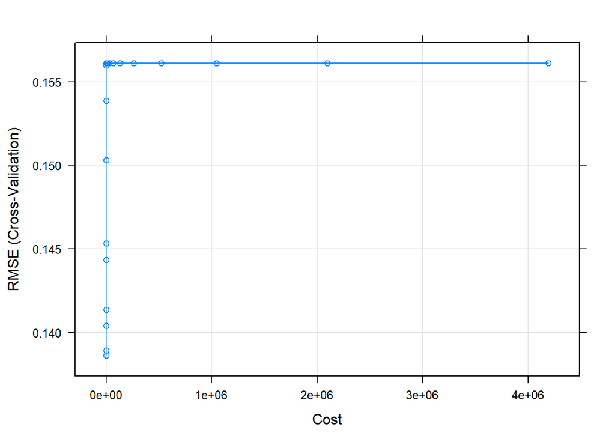

Support vector machine algorithm has some advantage over linear regression in that it minimize the effect of outliers.

In linear regression even one outlier can influence parameter estimation, but SVM uses the Square to residuals when the abosulte outliers are small while uses the absolute residuals when the absolute residuals are large. By this “weighted effect”, the mangitude of outlier influence is minimized.

Because our data contains quite a few outliers in a few of the observations ,we expect that SVM will give us a more robust prediction than linear model.

### KNN Model

```
##             Length Class      Mode
## learn        2     -none-     list
## k            1     -none-     numeric
## theDots      0     -none-     list
## xNames      33     -none-     character
## problemType  1     -none-     character
## tuneValue    1     data.frame list
## obsLevels    1     -none-     logical
## param        0     -none-     list
```

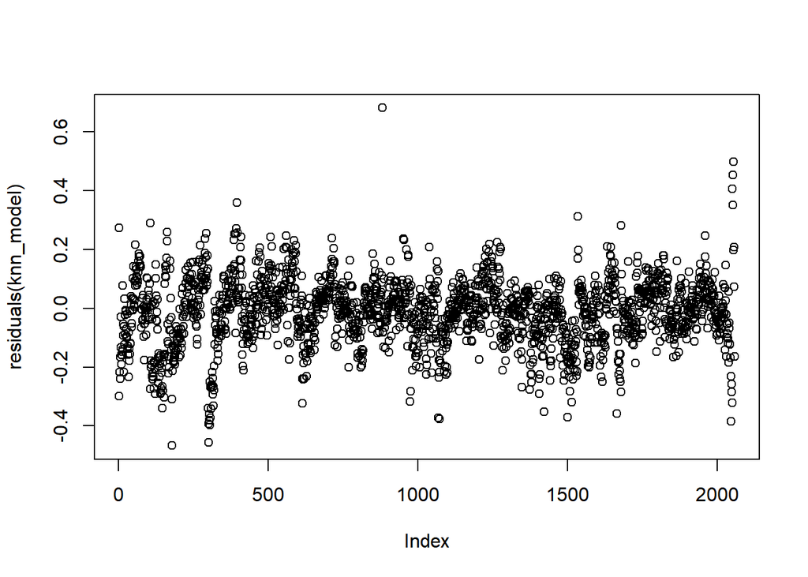

KNN, which stands for K nearest neighbors model, utilizes the K closest samples (Usually in means)from the training set to predict. Its prediction power can be negatively influenced by different skills of predictions, which generates unbalanced distance. Because the 33 variables of ours have such issue, we utilized the Options of centered and scaled predictors to overcome this issue.

As with other model, 10 folds of cross validation were chosen, and 25 tuning algorithm within the KNN modeling were specified. The models evaluation were bind into the models_test_evaluation data frame, to compared with other models.

### Random Forest

```
##                 Length Class      Mode
## call               4   -none-     call
## type               1   -none-     character
## predicted       2058   -none-     numeric
## mse              500   -none-     numeric
## rsq              500   -none-     numeric
## oob.times       2058   -none-     numeric
## importance        33   -none-     numeric
## importanceSD       0   -none-     NULL
## localImportance    0   -none-     NULL
## proximity          0   -none-     NULL
## ntree              1   -none-     numeric
## mtry               1   -none-     numeric
## forest            11   -none-     list
## coefs              0   -none-     NULL
## y               2058   -none-     numeric
## test               0   -none-     NULL
## inbag              0   -none-     NULL
## xNames            33   -none-     character
## problemType        1   -none-     character
## tuneValue          1   data.frame list
## obsLevels          1   -none-     logical
## param              0   -none-     list
```

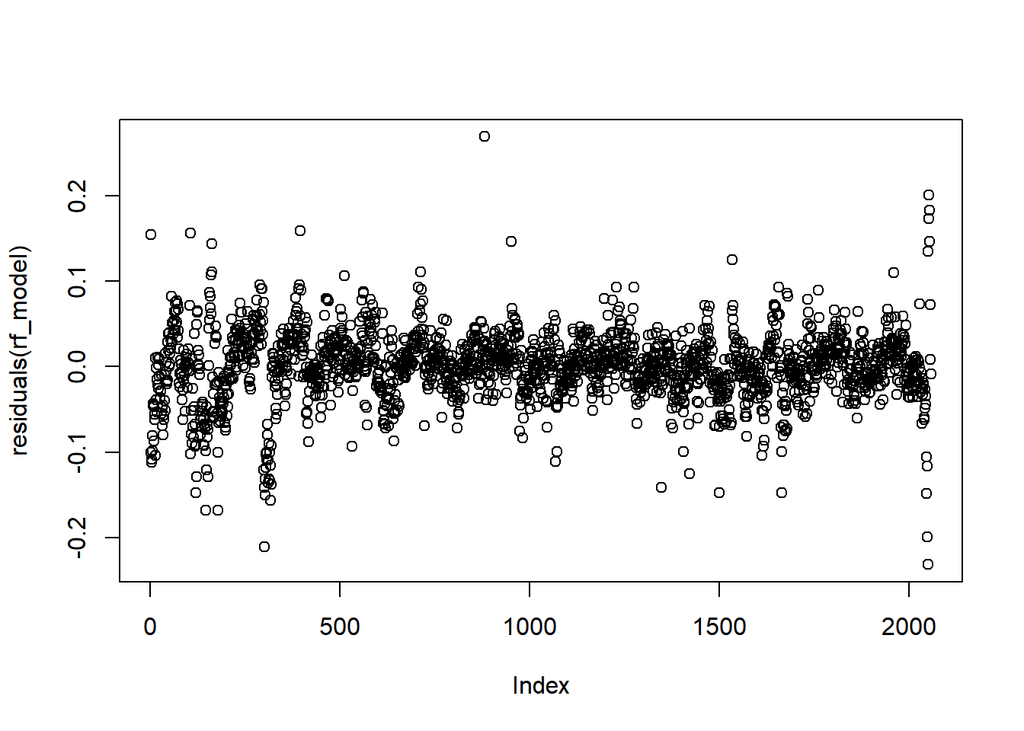

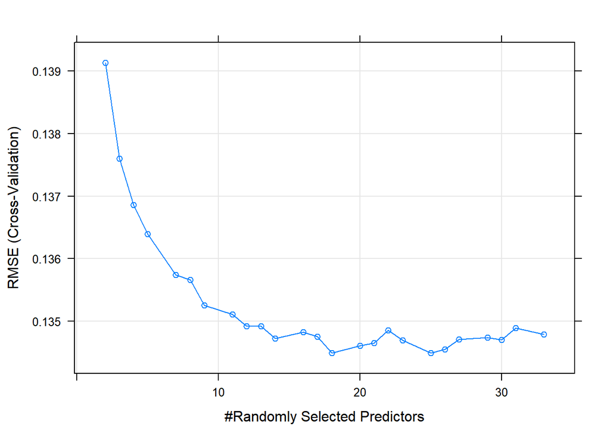

Random forest is one step further of the bagged tree model, but it differs from the simple bagged tree samples that it completely removes the inter-dependency of bootstrap samples from regular tree models. It reduces the correlation among predictors by and adding randomness to the construction process, hence with the name random forest.

As with other models, we specified 10 cross validations, 25 tuning algorithms, and we export the model evaluators for future comparisons.

### Cubist Model

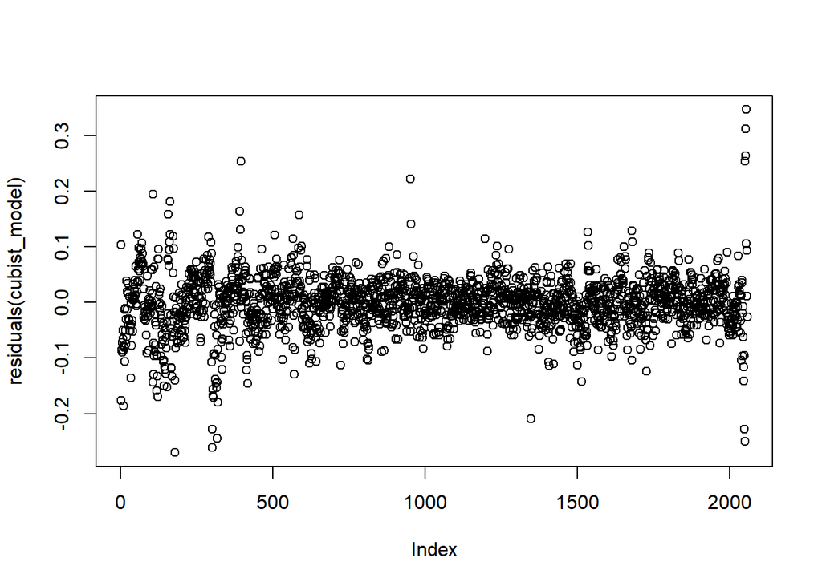

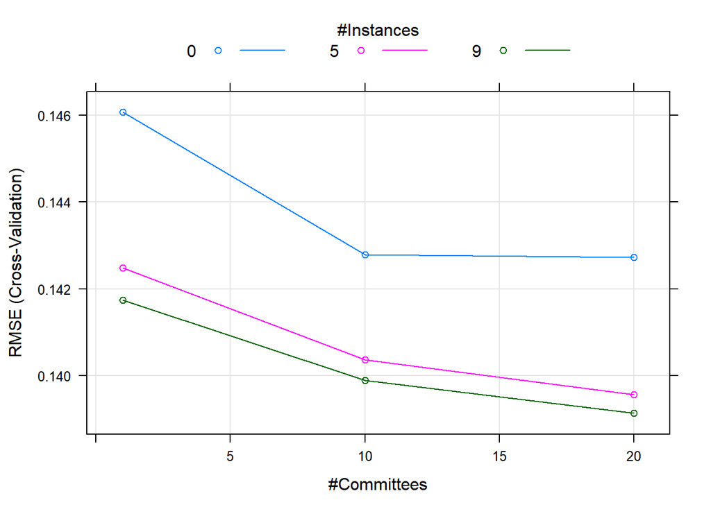

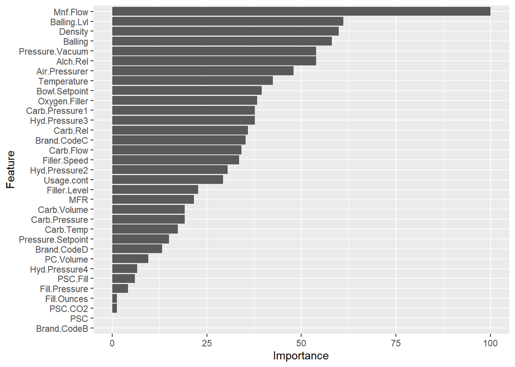

Cubist is a rule-based machine learning model. A rule based machine learner has one step further than the tree based modeling, in that is the identification and utilization of a set of relational rules that collectively represent the knowledge. In contrast to Tree based models, Which generate machine learning rule (also only SINGLE set of rule is applied) within it self, or in other case, uses only one rule universally across all the algorithms.

A cute best model resembles a piecewise linear model to predict numeric values, except that the rules can overlap.

### Multivariate Adaptive Regression Splines (MARS)

```
## Call: earth(x=matrix[2058,33], y=c(8.36,8.94,8.2...), keepxy=TRUE, degree=1,
##             nprune=3)
##
##                 coefficients
## (Intercept)        8.4891451
## Brand.CodeC       -0.1383435
## h(0.2-Mnf.Flow)    0.0016105
##
## Selected 3 of 22 terms, and 2 of 33 predictors (nprune=3)
## Termination condition: RSq changed by less than 0.001 at 22 terms
## Importance: Mnf.Flow, Brand.CodeC, Brand.CodeB-unused, Brand.CodeD-unused, ...
## Number of terms at each degree of interaction: 1 2 (additive model)
## GCV 0.02094275    RSS 42.89101    GRSq 0.2901952    RSq 0.292953
```

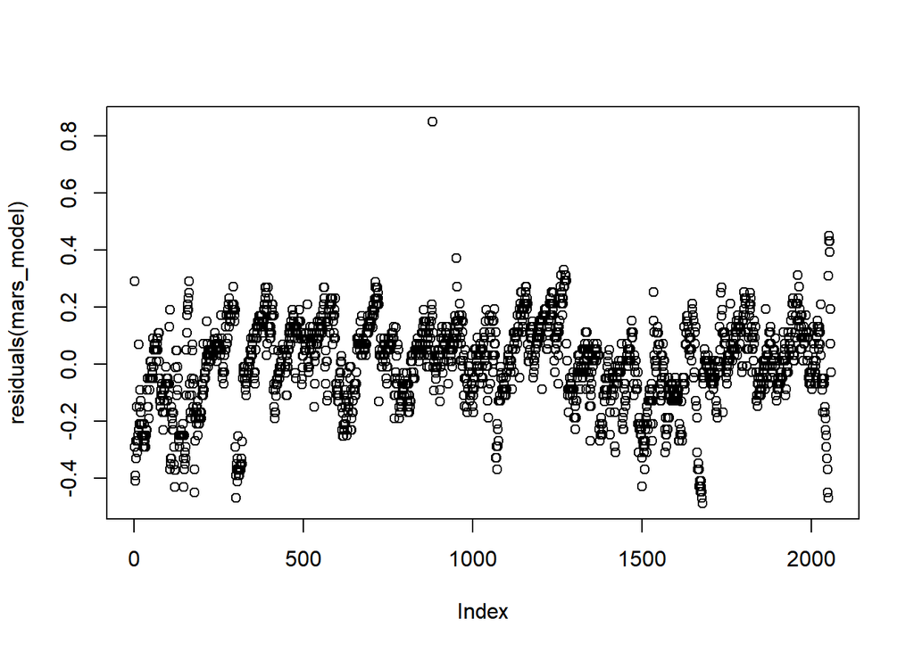

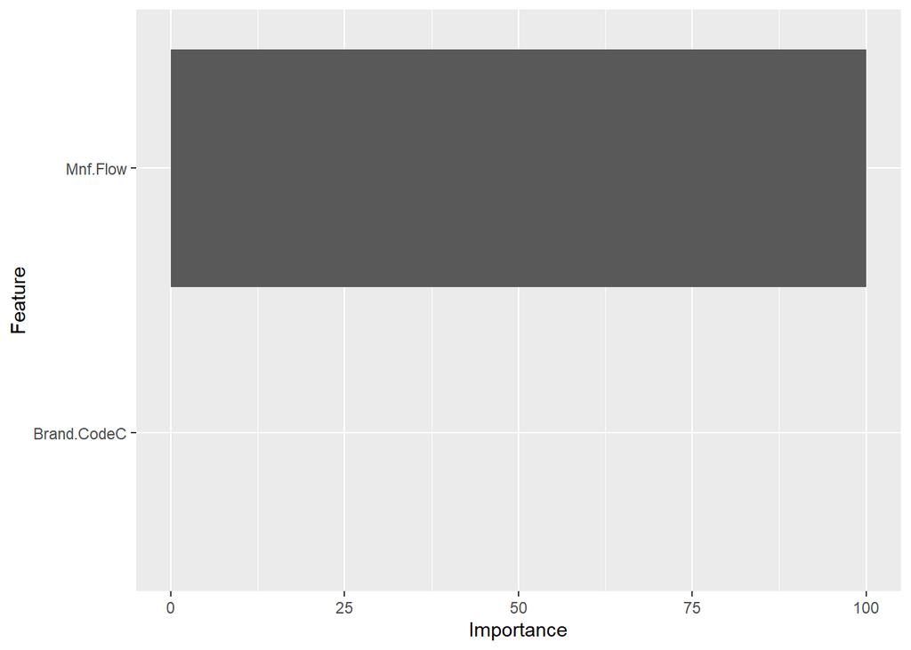

Due to the strict assumption of linearity between predictors and outcome, problem arise when multiple variables, in our case, 33 predictors are in presence, many of whom do not have the perfect linear relationship with the outcome. Such problem might be solved by introducing some nonlinearity in the model, such as to supplement the previous linear regression model with additional complexity. Adding a squared term, or even higher dimensional term, for some variables, or introducing interaction term with two correlated variables. But the model can be overly complex by such, which introduces many more unnecessary variables in addition to the existing 33 variables, which exacerbates the overfitting problem even further.

The multivariate adaptive regression spline (MARS) model is a solution to such dilemma. When used with a single predictor, MARS can fit separate linear regression lines for different ranges of engine displacement. The slopes and intercepts are estimated for this model, as well as the number and size of the separate regions for the linear models.

## Model Evalution Summary

```
##           Model       RMSE  Rsquared        MAE
## 1          MARS 0.14542857 0.3143190 0.11438384
## 2        Cubist 0.09207475 0.7254765 0.06671164
## 3 Random Forest 0.09390085 0.7291957 0.06885157
## 4          KNN  0.11969112 0.5419179 0.09081871
## 5           SVM 0.11525275 0.5719417 0.08339187
## 6  Bagged-Tree  0.11029114 0.6086628 0.08150475
```

The table above shows our models performance.We evaluated models using below criteria:

1. R^2

2. *Root Mean Squared Error*

RMSE is interpreted as how far, on average, the residuals are from zero.

3. *Mean Absolute Error* (MAE)

The MAE value follows exactly the same pattern as RMSE. The best the performers are cubist, random forest model. While the worst performer is MARS. The rest of three models perform similarly.

Based on what we’ve seen above table Cubist model gives best performance among the other models.So we are going to select Cubist models as champion model and predict values by using evaluation dataset and export in excel file.

Taking into all considerations of RMSE, R squared, MAE, Cubist is our best model. Random forest model follows very closely to Cubist.